# 07-graph-evolution

Marie Plessz

07/12/2020

##objectif graphique des évolutions des pratiques intensives, selon le traitement (cad selon qu’en emploi ou chômeur en 2017).

Je pars du fichier préparé en `05b-import-propsectif.Rmd`.

J’ai choisi de représenter à la fois le fait de *fumer **et le fait de fumer de façon intensive.** nb** : si je dois reprendre ces graphiques, pour mettre tous les éléments (layers) communs au graphe dans un objet, voici la technique (il faut descendre un peu sru la page) : https://stackoverflow.com/questions/18747091/reuse-ggplot-layers-in-multiple-plots

# données, fonctions, labels communs

```r
data_orig <- readRDS( "Data/Cree/HDR6_05b-cc-vardep-long.Rds")

# fonction pour le début, commun à différents graphiques
f_pivot <- function(df, vars) {
    df %>%
        pivot_longer(cols = c(inc, sui), names_to = "Phase", values_to = "value") %>%
        select(proj_isp, vardep, Phase,  traitt, value) %>%
        filter(vardep %in% varlist) %>%
        mutate_at(vars(vardep, Phase, traitt), as.factor)
}
```

==> si je dois changer l’ordre : mettre les vars dans l’ordre qui me convient, générer une var = au rang dans le tableau, et l’appeler ordre.

On ne traite pas la variable value à ce stade, elle doit rester character, car elle contient aussi bien les valeurs numériques (fum_n, alc_n) que les valeurs “facteur” (jamais, 1/semaine etc).

```r
effectifs_complets <- readRDS("Doc/HDR6_05b-vardep-effectifs-complets.Rds")

# ajouter les infos contenues dans le petit tableau csv importé au début, et composer le titre
labels_vars<- tribble(
    ~vardep,    ~vartitre,      ~intense,           ~ordre,
    "alc_i",    "Alcool",       "2 verres/jour",    5,
    "fum_i",     "Cigarettes",  "10/jour",          8,
    "fum_p",     "Fumeur",      "Oui",              7,
    "leg_i",     "Légumes" ,    "1/jour",           1,
    "poi_i",     "Poisson" ,    "2/semaine",        2,
    "vro_i",     "Viande rouge","4/semaine",        3,
    "sod_i",     "Boissons sucrées", "1/semaine",   6,
 "fas_i",    "Fastfood" ,   "1/semaine",        4  ,
 "bmi_i",    "Corpulence" , "Obèse",            9,
 "san_i",    "Mauvaise santé", "1-5/8",         10
)   %>%
    rename("vardep_i" = "vardep") %>%
    mutate(vardep_o = str_replace(vardep_i, "_i", "_o")) %>%
    mutate_at(vars(vartitre, vardep_i, vardep_o), as.character) %>%
    pivot_longer(cols = starts_with("vardep"), names_to = "truc", values_to = "vardep", names_prefix = "vardep") %>%
    select(-truc) %>%
    right_join(effectifs_complets, by = "vardep") %>%
    arrange(ordre)  %>%
    mutate_at(vars(vartitre, vardep), as.character) %>%
    mutate_at(vars(vartitre, vardep), fct_inorder)
```

# graphiques évolutions

### Préparer les data au format long et avec les moyennes

```r
# variables dépendantes : inclure bmi et santé
# varlist <- unique(data_orig$vardep) %>% str_subset("_i")
# varlist <- c(varlist , "fum_p")

# variables dépendantes : sélection pour GoCho
varlist <- c("alc_i", "fum_i", "leg_i", "sod_i", "poi_i", "vro_i", "fas_i", "fum_p")

dfl <- f_pivot(data_orig, vars = varlist)  %>%

# calculer les moyennes par phase * traitement * variable

    mutate(intense = as.numeric(value)) %>%
    group_by(vardep, Phase, traitt ) %>%
    summarise(pct = mean(intense))
```

Variables retenues : alc_i, fum_i, leg_i, sod_i, poi_i, vro_i, fas_i, fum_p.

### titres

Le package `glue` me permet de composer le titre à partir du contenu des variables.

J’importe les effectifs stockés dans un objet à l’étape `05b-import-propsectif.Rmd`

Ensuite, je passe le `titre` en facteur et je l’ordonne d’après la variable `ordre`.

```r
df_titre <- labels_vars %>%
    filter(vardep %in% varlist) %>%

    mutate(titre = glue("{vartitre}: {intense} (n= {n})")) %>%
    mutate(titre = as.factor(titre)) %>%
    arrange(ordre)  %>%
    select(vardep, vartitre, titre)

# ordre des levels de titre
df_titre$titre <- fct_inorder(df_titre$titre)

# ajouter  les titres aux données
df_graph <- dfl %>%
    left_join(df_titre, by = "vardep") %>%
        mutate_at(vars(vardep, Phase, traitt), as.factor) %>%
    mutate(Phase = fct_recode(Phase,
                                                         "Inclusion" = "inc",
                                                        "2017" = "sui"  ))

var_label(df_graph) <- list(traitt = "En 2017")
```

### Graphique

Pour grouper des lignes il faut **à la fois** les options `color`et `group`.

Le nom du fichier dans lequel est sauvé le graphique est composé au début du fichier, d’après mon `tag`.

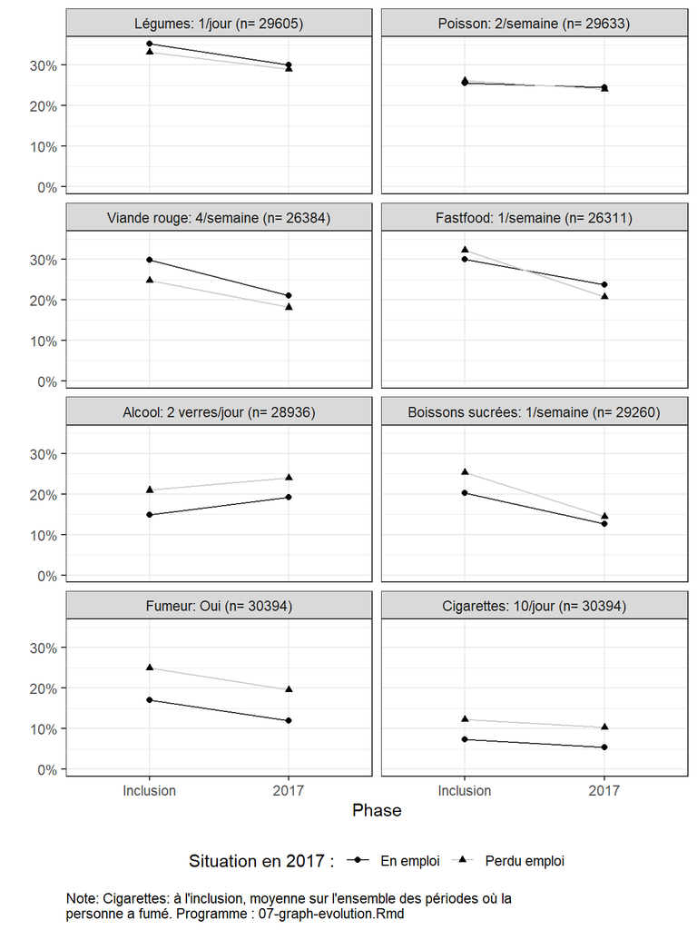

```r
footnote <- glue("Note: Cigarettes: à l'inclusion, moyenne sur l'ensemble des périodes où la personne a fumé. \n\n
                    Programme : {tag}.Rmd")

gr_evolutions <-
    df_graph %>%    ggplot() +
        geom_line(aes(x = Phase, y =  pct, group = traitt, color = traitt),
                            stat = "identity") +
    scale_color_grey() +
     geom_point(aes(x = Phase, y =  pct, shape = traitt))   +
        facet_wrap(~ titre, scales = "fixed", ncol = 2 )  +
        theme_bw() +
    ylab("") +
        scale_y_continuous(labels = scales::percent_format(accuracy = 1), limits = c(0, NA)) +
        theme(legend.position = "bottom",
            #   legend.title = element_blank(),
                plot.caption = element_text(hjust = 0)) +
        labs(caption = str_wrap(footnote, 80)) +
      guides(color=guide_legend("Situation en 2017 :")) +
      guides(shape=guide_legend("Situation en 2017 :"))


print(gr_evolutions)
```

```r
# nom du fichier de sortie:
myfile <- glue("Resultats/{tag}-01-selon-emploi-2017.png")
myjpg <- glue("Resultats/{tag}-01-selon-emploi-2017.jpg")
ggsave(myfile, plot = gr_evolutions, width = 6, height = 8)
ggsave(myjpg, plot = gr_evolutions, width = 6, height = 8)
```

# Distribution vars détaillées

## Alimentation

```r
# liste des variables représentées
varlist <- unique(data_orig$vardep) %>% str_subset("_o")

# modalités des fréquences par ordre croissant
list_ordre_freq <- c( "Jamais",
                                                                             "<1/semaine",
                                                                             "Max 1/semaine" ,
                                                                                "1/semaine",
                                                                              "Min 1/semaine",
                                                                            "2-3/semaine",
                                                                             "Min 2/semaine" ,
                                                                             "Min 4/semaine",
                                                                             "4-6/semaine" ,
                                                                               "Min 1/jour"
                                                                             )

dfl2 <- f_pivot(data_orig, vars = varlist) %>%
    mutate(value = as.factor(value)) %>%
        mutate(value = fct_recode (value, "<1/semaine" = "< 1/semaine")) %>%
    mutate(value = fct_relevel(value, list_ordre_freq )) %>%
    group_by(vardep, Phase,  value ) %>%
        count (name = "cat") %>%
    group_by(vardep, Phase ) %>%
    mutate(total = sum(cat)) %>%
    mutate(pct = cat / total ) %>%


    left_join(labels_vars, by = "vardep") %>%
    select(-intense) %>%
    mutate(Phase = fct_recode(Phase, "Inclusion" = "inc",
                                                        "2017" = "sui"))
```

### Graphique

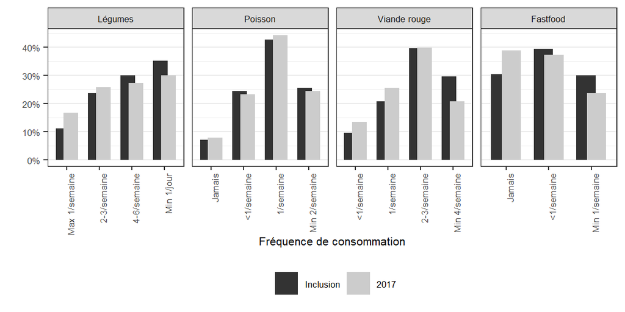

```r
dfl2 %>% filter(vartitre %in% c(  "Légumes", "Poisson", "Viande rouge",  "Fastfood")) %>%
    ggplot() +
    geom_bar(aes(x = value, y = pct, fill = Phase),
                        stat = "identity", position = position_dodge(width = 0.5)) +
    ylab("") +
    scale_y_continuous(labels = scales::percent_format(accuracy = 1)) +
    xlab("Fréquence de consommation") +
    facet_grid(cols = vars(vartitre),
                         scales = "free") +
    theme_bw() +
    scale_fill_grey() +
    theme(legend.position = "bottom",
                legend.title = element_blank(),
                                panel.grid.major.x = element_blank(),
                panel.grid.minor.x = element_blank(),
                plot.caption = element_text(hjust = 0)) +
     theme(text = element_text(size=8),
        axis.text.x = element_text(angle=90, hjust=1))
```

```r
    labs(caption = glue("Programme : {tag}.Rmd"))
```

```
## $caption
## Programme : 07-graph-evolution.Rmd
##
## attr(,"class")
## [1] "labels"
```

```r
# nom du fichier de sortie:
myfile <- glue("Resultats/{tag}-alim.png")

ggsave(myfile, width = 6, height = 3)
```

### chiffres pour texte

```r
# Poisson

 dfl2 %>% filter(vardep == "leg_o" & Phase == "Inclusion" )  %>%
    select(-cat, -total, -ordre, -n)
```

```
## # A tibble: 4 x 5
## # Groups:   vardep, Phase [1]
##   vardep Phase     value           pct vartitre
##   <fct>  <fct>     <fct>         <dbl> <fct>
## 1 leg_o  Inclusion Max 1/semaine 0.112 Légumes
## 2 leg_o  Inclusion 2-3/semaine   0.236 Légumes
## 3 leg_o  Inclusion 4-6/semaine   0.300 Légumes
## 4 leg_o  Inclusion Min 1/jour    0.352 Légumes
```

```r
dfl2 %>% filter(vardep == "poi_o" & Phase == "Inclusion" ) %>%
    select(-cat, -total, -ordre, -n)
```

```
## # A tibble: 4 x 5
## # Groups:   vardep, Phase [1]
##   vardep Phase     value            pct vartitre
##   <fct>  <fct>     <fct>          <dbl> <fct>
## 1 poi_o  Inclusion Jamais        0.0711 Poisson
## 2 poi_o  Inclusion <1/semaine    0.245  Poisson
## 3 poi_o  Inclusion 1/semaine     0.428  Poisson
## 4 poi_o  Inclusion Min 2/semaine 0.256  Poisson
```

```r
dfl2 %>% filter(vardep == "fas_o" & Phase == "Inclusion" ) %>%
    select(-cat, -total, -ordre, -n)
```

```
## # A tibble: 3 x 5
## # Groups:   vardep, Phase [1]
##   vardep Phase     value           pct vartitre
##   <fct>  <fct>     <fct>         <dbl> <fct>
## 1 fas_o  Inclusion Jamais        0.304 Fastfood
## 2 fas_o  Inclusion <1/semaine    0.395 Fastfood
## 3 fas_o  Inclusion Min 1/semaine 0.301 Fastfood
```

```r
 dfl2 %>% filter(vardep == "alc_o" & Phase == "Inclusion" )  %>%
    select(-cat, -total, -ordre, -n)
```

```
## # A tibble: 4 x 5
## # Groups:   vardep, Phase [1]
##   vardep Phase     value   pct vartitre
##   <fct>  <fct>     <fct> <dbl> <fct>
## 1 alc_o  Inclusion 0     0.185 Alcool
## 2 alc_o  Inclusion 1     0.459 Alcool
## 3 alc_o  Inclusion 2     0.212 Alcool
## 4 alc_o  Inclusion 3     0.143 Alcool
```

## Boisson

```r
g_soda <- dfl2 %>% filter(vardep %in% c("sod_o")) %>%
    ggplot() +
    geom_bar(aes(x = value, y = pct, fill = Phase),
                        stat = "identity", position = position_dodge(width = 0.5)) +
    ylab("") +
     scale_y_continuous(labels = scales::percent_format(accuracy = 1)) +
    xlab("Fréquence de consommation") +
        theme_bw() +
    scale_fill_grey() +
    theme(legend.position = "bottom",
                legend.title = element_blank(),
                                panel.grid.major.x = element_blank(),
                panel.grid.minor.x = element_blank(),
                plot.caption = element_text(hjust = 0)) +
     theme(text = element_text(size=8)) # +
#   labs(caption = glue("Programme : {tag}.Rmd"))



# nom du fichier de sortie:
myfile <- glue("Resultats/{tag}-soda.png")

ggsave(myfile, width = 3, height = 3)
```

```r
varlist <- "alc_n"
df_alc <- f_pivot(data_orig, varlist) %>%
    mutate(value = as.numeric(as.character(value))) %>%
    mutate(value = if_else(value<10, value, 10 )) %>%
    mutate(value = if_else(value == 0, -1, value )) %>%
    mutate(value = labelled(value, c("10 ou +" = 10)))  %>%
    mutate(Phase = fct_recode(Phase, "Inclusion" = "inc",
                                                        "2017" = "sui"))

summary(df_alc$value)
```

```
##    Min. 1st Qu.  Median    Mean 3rd Qu.    Max.
## -1.0000  0.3000  0.7000  0.9357  1.4000 10.0000
```

```r
dim(df_alc[df_alc$Phase == "Inclusion", ])
```

```
## [1] 28899     5
```

```r
# foo2 <- foo %>% filter(Phase == "inc") %>%
#   mutate(v0 = case_when( value == 0 ~ "n0",
#                                                is.na(value) ~ "mqt",
#                                               TRUE ~ as.character(value) ))


g_alc <- df_alc %>%
    ggplot() +
    geom_histogram(aes(x = value, y = ..density.., fill = Phase)                             ,
                     position = position_dodge(width = 0.5),
                     binwidth = 1) +
    xlim(c(-0.5, 11)) +
    scale_x_continuous(breaks = c(-1, 0, 1:9, 10), labels = c(0, "<1", 1:9, "10 ou +") ) +
    ylab("") +
    xlab("Verres/jour") +
 scale_y_continuous(labels = scales::percent_format(accuracy = 1))  +
        theme_bw() +
    scale_fill_grey() +
    theme(legend.position = "bottom",
                legend.title = element_blank(),
                panel.grid.major.x = element_blank(),
                panel.grid.minor.x = element_blank(),
                plot.caption = element_text(hjust = 0)) +
     theme(text = element_text(size=8))
#   labs(caption = glue("Programme : {tag}.Rmd"))


# nom du fichier de sortie:
myfile <- glue("Resultats/{tag}-alcool.png")

ggsave(myfile, width = 4, height = 3)
```

```r
g_soda <- g_soda + ggtitle("Boissons sucrées")  +
     theme(text = element_text(size=10))
g_alc <- g_alc + ggtitle("Boissons alcoolisées")  +
     theme(text = element_text(size=10))

myfile <- glue("Resultats/{tag}-soda-alcool.png")

g_boiss <- ggpubr::ggarrange(g_soda, g_alc, common.legend = TRUE,  widths = c(2,3), legend="bottom")
g_boiss %>%
    ggpubr::ggexport(filename = myfile, width = 8*72, height = 3*72)
```

```
## file saved to Resultats/07-graph-evolution-soda-alcool.png
```

## Tabac

la variable `fum_control` et `fum_p` portent sur “fumer du tabac”.

le nb de cigarettes porte sur les cigarettes uniquement.

### d’abord combien ont commencé ou recommencé à fumer?

```r
foo <- data_orig %>% filter(vardep == "fum_p") %>%  select(sui, fum_control ) %>%
    mutate(sui = fct_recode(sui, "Fume en 2017" = "1", "Ne fume pas en 2017" = "0")) %>%
    group_by(fum_control, sui)

# arrêts et reprise
foo %>%
    count %>%
    kable( col.names = c("A l'inclusion", "En 2017", "n"))
```

| A l’inclusion | En 2017 | n |
| --- | --- | --- |
| Non fumeur | Ne fume pas en 2017 | 15190 |
| Non fumeur | Fume en 2017 | 20 |
| Fumeur | Ne fume pas en 2017 | 2067 |
| Fumeur | Fume en 2017 | 3183 |
| Ex-fumeur | Ne fume pas en 2017 | 9428 |
| Ex-fumeur | Fume en 2017 | 506 |

```r
lprop(table(foo$fum_control, foo$sui)) %>%  kable(digits = 1)
```

|  | Ne fume pas en 2017 | Fume en 2017 | Total |
| --- | --- | --- | --- |
| Non fumeur | 99.9 | 0.1 | 100 |
| Fumeur | 39.4 | 60.6 | 100 |
| Ex-fumeur | 94.9 | 5.1 | 100 |
| Ensemble | 87.8 | 12.2 | 100 |

```r
 data_orig %>% filter(vardep == "fum_n") %>%  select(proj_isp, sui, inc, fum_control) %>%
    group_by(fum_control) %>%
    summarise_at(vars(inc, sui), min) %>%
    kable(col.names = c("inclusion", "min(fum_n_inc)", "min(fum_n_sui)"))
```

| inclusion | min(fum_n_inc) | min(fum_n_sui) |
| --- | --- | --- |
| Fumeur | 1 | 0 |
| Ex-fumeur | 0 | 0 |

`fum_p` vaut 0 si `fum_control` = Non-fumeur.

En revance le nb de cigarettes fumées est manquant si `fum_control` = Non-fumeur.

```r
# fum_control pour tout le monde.
df_control <- data_orig %>% filter(str_detect(vardep, "fum"))   %>%
    select(proj_isp, fum_control, inc, sui, vardep) %>%
        pivot_longer(cols = c(inc, sui), names_to = "Phase", values_to = "value") %>%
    filter(vardep == "fum_p") %>%
    select(-vardep, -value)

freq(df_control$fum_control, total = T)
```

```
##                n     %  val%
## Non fumeur 30420  50.0  50.0
## Fumeur     10500  17.3  17.3
## Ex-fumeur  19868  32.7  32.7
## Total      60788 100.0 100.0
```

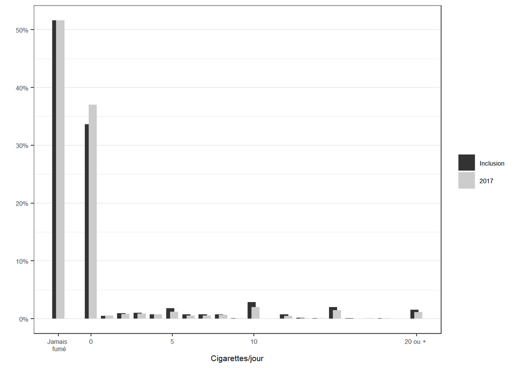

```r
varlist <- c("fum_n")
df_cig <- data_orig %>%
    f_pivot( varlist) %>%
    right_join(df_control, by = c("proj_isp", "Phase"))  %>%
        mutate_at(vars(vardep, Phase, traitt), as.factor) %>%
    mutate(Phase = fct_recode(Phase, "Inclusion" = "inc",
                                                        "2017" = "sui"))    %>%
    mutate(value = as.numeric(as.character(value))) %>%
# si jamais fumé, value = -1
    mutate(valcig = case_when((fum_control == "Non fumeur" & is.na(value)) ~ -2,
                                                        TRUE ~ value ))
# pour vérifier
        # df_cig %>%
        # group_by(value, valcig) %>%  count
# test qu'on a le bon nb de lignes à l'inclusion
stopifnot(
    dim(df_cig[df_cig$Phase == "Inclusion", ])[[1]] == dim(df_control[df_control$Phase == "inc", ])[[1]]
    )

# graph
df_cig %>%
    mutate(valcig = if_else(valcig<20, valcig, 20 )) %>%
    ggplot() +
    geom_histogram(aes(x = valcig, y = ..density.., fill = Phase, group = Phase) ,
                     position = position_dodge(width = 0.5),
                     binwidth = 1) +
    xlim(c(-3, 21)) +
    scale_x_continuous(breaks = c(-2, 0, 5, 10, 20),
                                         labels = c("Jamais \n fumé", 0, 5, 10 , "20 ou + ")) +
    ylab("") +
    xlab("Cigarettes/jour") +
 scale_y_continuous(labels = scales::percent_format(accuracy = 1))  +
        theme_bw() +
    scale_fill_grey() +
    theme(legend.position = "right",
                legend.title = element_blank(),
                panel.grid.major.x = element_blank(),
                panel.grid.minor.x = element_blank(),
                plot.caption = element_text(hjust = 0)) +
     theme(text = element_text(size=8))
```

```r
    labs(caption = glue("Programme : {tag}.Rmd"))
```

```
## $caption
## Programme : 07-graph-evolution.Rmd
##
## attr(,"class")
## [1] "labels"
```

```r
# nom du fichier de sortie:
myfile <- glue("Resultats/{tag}-cig.png")

ggsave(myfile, width = 4, height = 2)
```

# Graphique supplémentaire alim x phase x traitt

```r
varlist <- unique(data_orig$vardep) %>% str_subset("_o")
dfl3 <- f_pivot(data_orig, vars = varlist) %>%
    mutate(value = as.factor(value)) %>%
    mutate(value = fct_recode (value, "<1/semaine" = "< 1/semaine")) %>%
    mutate(value = fct_relevel(value, list_ordre_freq)) %>%
    group_by(vardep, Phase, traitt, value ) %>%
    count (name = "cat") %>%
    group_by(vardep, Phase, traitt ) %>%
    mutate(total = sum(cat)) %>%
    mutate(pct = cat / total ) %>%
    mutate(value = fct_recode (value, "<1/semaine" = "< 1/semaine")) %>%

    left_join(labels_vars, by = "vardep") %>%
    select(-intense) %>%
    mutate_at(vars( traitt), as.factor) %>%
    mutate(Phase = fct_recode(Phase, "Inclusion" = "inc",
                                                        "2017" = "sui")) %>%
    filter(vartitre %in% c(  "Légumes", "Poisson", "Viande rouge",  "Fastfood"))
```

[output not shown]

[output cut: 16 more lines]

[output not shown]

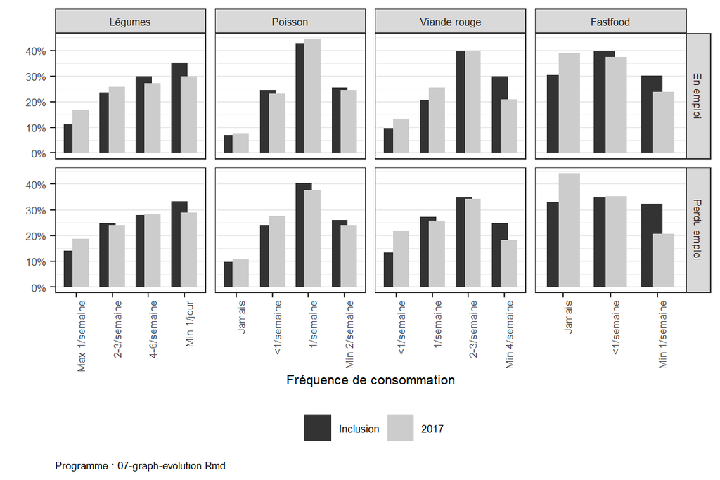

```r
dfl3 %>%
    ggplot() +
    geom_bar(aes(x = value, y = pct, fill = Phase),
                     stat = "identity", position = position_dodge(width = 0.5)) +
    ylab("") +
    scale_y_continuous(labels = scales::percent_format(accuracy = 1)) +
    xlab("Fréquence de consommation") +
    facet_grid(cols = vars(vartitre), rows = vars(traitt),
                         scales = "free") +
    theme_bw() +
    scale_fill_grey() +
    theme(legend.position = "bottom",
                legend.title = element_blank(),
                panel.grid.major.x = element_blank(),
                panel.grid.minor.x = element_blank(),
                plot.caption = element_text(hjust = 0)) +
    theme(text = element_text(size=8),
                axis.text.x = element_text(angle=90, hjust=1)) +
labs(caption = glue("Programme : {tag}.Rmd"))
```

```r
# nom du fichier de sortie:
myfile <- glue("Resultats/{tag}-alim-traitt.png")

ggsave(myfile, width = 6, height = 4)
```

### graphiques évoluions faible conso

```r
varlist <- unique(data_orig$vardep) %>% str_subset("_f")

df_faible <- f_pivot(data_orig, vars = varlist)  %>%

# calculer les moyennes par phase * traitement * variable

    mutate(faible = as.numeric(value)) %>%
    group_by(vardep, Phase, traitt ) %>%
    summarise(pct = mean(faible))
```

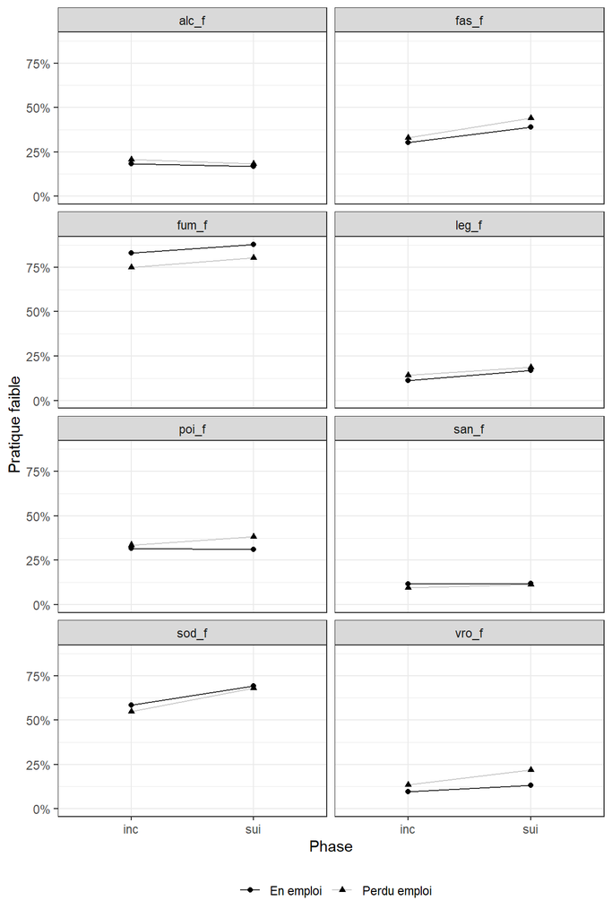

```r
df_faible %>%   ggplot() +
    geom_line(aes(x = Phase, y =  pct, group = traitt, color = traitt),
                        stat = "identity") +
scale_color_grey() +
 geom_point(aes(x = Phase, y =  pct, shape = traitt))   +
    ylab("Pratique faible")  +
    facet_wrap(~ vardep, scales = "fixed", ncol = 2 )  +
    theme_bw() +
    scale_y_continuous(labels = scales::percent_format(accuracy = 1), limits = c(0, NA)) +
    theme(legend.position = "bottom",
                legend.title = element_blank(),
                plot.caption = element_text(hjust = 0))
```

```r
# nom du fichier de sortie:
myfile <- glue("Resultats/{tag}-evol-faible.png")

ggsave(myfile, width = 6, height = 7)
```